# Der Effekt von Earnings-Conference Calls am Aktienmarkt

# Motivation

Earnings Conference Calls sind zentrale Informationsereignisse in Finanzmärkten. Hier kommuniziert das Management direkt mit Investoren und Analysten über die aktuelle Geschäftslage und Zukunftsaussichten. Die finanzwirtschaftliche Forschung zeigt, dass diese Calls erhebliche Kursbewegungen auslösen können - doch die zugrundeliegenden Mechanismen sind noch nicht vollständig verstanden.

Während traditionelle Finanztheorie von effizienten Märkten ausgeht, die alle verfügbaren Informationen sofort verarbeiten, zeigen empirische Studien, dass die Art der Kommunikation und das Sentiment der Aussagen eigenständige Erklärungskraft für Aktienkursreaktionen besitzen. Diese Erkenntnisse haben direkte praktische Relevanz: Banken nutzen Sentiment-Analysen für algorithmische Handelsstrategien, Hedge Fonds entwickeln systematische Ansätze zur Textauswertung, und Asset Manager integrieren qualitative Informationen in ihre Bewertungsmodelle.

In diesem Projekt kombinieren Sie Event Studies - eine etablierte Methode der empirischen Finanzforschung zur Messung von Informationseffekten - mit modernen Large Language Models zur systematischen Textanalyse. Sie untersuchen, ob und wie sich qualitative Aussagen des Managements in quantifizierbaren Marktreaktionen niederschlagen, und lernen dabei sowohl die methodischen Grundlagen der Kausalitätsidentifikation als auch den praktischen Umgang mit KI-gestützten Finanzanalysen kennen.

# Event-Study-Methodik und theoretische Diskussion

1. Lesen Sie das Kapitel [“Event Studies” in Huntington-Klein (2021)](https://theeffectbook.net/ch-EventStudies.html) und beantworten Sie die folgenden Fragen dazu:

Kann eine Eventstudie helfen, den kausalen Effekt eines Earnings Conference Calls auf die Aktienrendite eines Unternehmens zu identifizieren? Gehen Sie bei der Beantwortung dieser Frage insbesondere auf die nachfolgenden Punkte ein:

- Welche Art von Variation nutzt eine Eventstudie zur Identifikation des Effekts?
- Welche Voraussetzung(en) müssen erfüllt sein, damit die Eventstudie eine gültige Kausalschätzung liefert?
  - Was bedeutet das “Joint-Test Problem” in diesem Kontext?

**Welche Art von Variation nutzt eine Eventstudie zur Identifikation des Effekts?**  
Eine Eventstudie nutzt die zeitliche Variation innerhalb eines Beobachtungszeitraums. Es werden Veränderungen in der Zeitreihe vor und nach einem spezifischen Ereignis betrachtet. Im Fall eines Earnings Calls vergleicht man die Kursveränderungen von davor mit den unmittelbaren Kursveränderungen nach dem Call.

**Welche Voraussetzungen müssen erfüllt sein, damit die Eventstudie eine gültige Kausalschätzung liefert?**  
Das untersuchte Event muss das einzige sein, dass die Zeitreihe unmittelbar beeinflusst. Das bedeutet, dass der Earnings Call das einzig relevante Ereignis im betrachteten Zeitraum sein muss. Zudem muss korrekt modelliert werden, wie sich die Zeitreihe ohne das Ereignis verhalten hätte. Für die Modellierung von Aktien werden hierfür Indices herangezogen, die viele Aktien ähnlichen Typs beinhalten.

**Joint-Test Problem**  
Das Joint-Test Problem beschreibt, dass bei einer Eventstudie immer 2 Dinge gleichzeitig getestet werden:

- Ob das Ereignis einen Effekt auf die Zeitreihe hat.
- Ob das Modell für die Vorhersage der Zeitreihe ohne Ereignis korrekt ist.

Im Kontext der Earnings Calls bedeutet das, dass nicht nur getestet wird, ob Earnings Calls eine Effekt auf die Rendite haben, sonder auch, ob die Rendite ohne Earnings Call korrekt vorhergesagt wird. Somit ist der gemessene Effekt eine Kombination des tatsächlichen Effekt des Earnings Calls und dem Fehler in der Vorhersage der Rendite ohne Earnings Call.

**Fazit**  
Eine Eventstudie kann helfen, den kausalen Effekt von Earnings Calls auf die Aktienrendite eines Unternehmens zu identifizieren, sofern die identifizierten Voraussetzungen geprüft werden.

# Daten und Datenaufbereitung

## Finanzmarktkennzahlen

2. Sie sollten in einem ersten Schritt Finanzkennzahlen aus Datastream herunterladen. Insbesondere sollten Sie den Return Index (RI) und die Total Assets (WC02999) für alle Firmen im Euro Stoxx 600 Technology Index ( wir haben Ihnen die RIC Kürzel in der Readme bereitgestellt ) vom 01.01.2020 bis heute extrahieren.

Bitte laden Sie für den Return Index tägliche Daten herunter und für die Total Assets Quartalsdaten. Weiterhin sollten Sie den Total Return Index (RI) des Euro Stoxx 600 (RIC = .STOXX) herunterladen (auch tägliche Daten). Bitte achten Sie darauf alle Daten **in Euro** herunterzuladen.

Achten Sie darauf die RIC als eindeutige Identifikationskennung in ihren Datensatz aufzunehmen.

Das Institut für Finanzwirtschaft der Universität Ulm hat einen ausführlichen [Guide zu Datastream](https://www.uni-ulm.de/fileadmin/website_uni_ulm/allgemein/Update_Introduction_Datastream_May_2025.pdf) erstellt, der Ihnen beim Download der Daten sicherlich helfen kann.

Die Universität Ulm stellt für den Download Remote-PCs zur Verfügung, auf die Sie sich von daheim aus einloggen können. Bitte buchen Sie sich hier einen Slot um Zugriff auf diese PCs zu erhalten: https://www.uni-ulm.de/mawi/iof/lehre/proposals-for-theses/datastream-and-workspace/

Sie sollten ihre Daten in Excel herunterladen und in ihrem Projekt im Unterordner `data` abspeichern.

*Hinweis 1:* Es empfiehlt sich zwei Tabellenblätter im Excel File anzulegen, eines für die täglichen Daten und eines für die Quartalsdaten

*Hinweis 2:* Datastream ist eine Datenbank, die Kennzahlen zur Finanzlage von börsennotierten Unternehmen weltweit beinhaltet. Die Lizenzen zu Datastream an der Universität Ulm werden von der Studienkommission Wirtschaftswissenschaften und der LBBW bezahlt und die Datenbank steht allen WiWi-Studierenden frei zur Verfügung. [Nähere Informationen zu Datastream finden Sie hier](https://www.uni-ulm.de/mawi/iof/lehre/proposals-for-theses/datastream-and-workspace/) (Bitte beachten: Sie müssen im Uninetz (z.B. über VPN) eingeloggt sein um die Informationen zu sehen und um sich auf die Remote-PCs loggen zu können).

*Hinweis 3:* Bei den Total Assets müssen Sie immer das Enddatum des vorherigen Jahres nehmen für den Download, d.h. Start Date wäre 31.12.2019

3. Lesen Sie die Excel Datei, welche Sie in Aufgabe 2 erstellt haben, in R ein. Achten Sie darauf, dass diese Daten tidy und richtig formatiert sind. Joinen Sie die täglichen Daten mit den Quartalsdaten für die relevanten Firmen. Die Quartalsdaten zählen für das komplette Quartal zu dem diese hinzugemerged wurden.

Setzen Sie sich mit den Aktienkursen auseinander und beantworten folgende Fragen: - Sie wollen in Aufgabe 4 *Renditen* berechnen, warum sollten Sie Daten zum “Total Return Index” und nicht dem “Price” oder “Unadjusted Price” herunterladen? Schauen Sie sich zur Klärung dieser Frage den [Guide der Uni Ulm zu Datastream](https://www.uni-ulm.de/fileadmin/website_uni_ulm/allgemein/Update_Introduction_Datastream_May_2025.pdf) genauer an. Diesen Guide sollten sie auch für den Download der Daten heranziehen.

*Hinweis:* In dem tidy Datensatz sollten Sie eine Spalte mit dem Unternehmensidentifier (RIC), eine mit dem Datum und eine mit der Variablen (RI bzw. Total Assets) haben

**Total Return Index, Price und Unadjusted Price - Wieso verwendet man den Total Return Index?**

Der Unadjusted Price ist der Preis, der historisch am Aktienmarkt gehandelt wurde. Dieser ist für diese Analyse nicht geeignet, da im Falle von Aktiensplits, dass bedeutet das Aufteilen von einer Aktie in mehrer Stücke, ein großer Kurssprung eintritt. Da es möglich ist, dass ein Aktiensplit in Folge eines Earnings Calls vorgenommen wird, kann dies das Ergebnis verzerren. Zudem gibt es beim Unadjusted Price, genau wie beim Price, ein Problem mit Dividendenzahlungen. Dies wird im Folgenden erläutert.

Der Price hat das Problem der Aktiesplits nicht, da diese und andere Kapitalmaßnahmen berücksichtigt werden. Jedoch werden Dividendenzahlungen nicht berücksichtigt. Bezahlt ein Unternehmen Dividende, dann schüttet es an einem Stichtag für jede Aktie einen Geldbetrag an den Aktienbesitzer aus. Am Stichtag verringert sich der Aktienkurs um diesen Geldbetrag. Davon kann jedoch nicht profitiert werden, da dieser Kursverlust allen Anlegern bereits zuvor bekannt ist und die Aktienbesitzer durch die Dividende einen Ausgleich erhalten. Dividenden werden meist nach Quartalsberichten und damit verbundenen Earnings Calls ausgeschütet. Wird nicht für Dividendenzahlungen korrigiert, könnte Earnings Calls fälschlicherweise ein negaiver Effekt unterstellt werden.

Der Total Return Index berücksichtigt Kapitalmaßnahmen und Dividendenzahlungen. Er kann als der bereinigte Wert einer Aktie interpretiert werden und ist deshalb ideal für diese Analyse.

## Renditen berechnen

4. In ihrem Datastream-Datensatz, welchen Sie in Aufgabe 2 bereits eingelesen und in Aufgabe 3 bearbeitet haben, sind die *Total Return Indices* (RI) der größten Unternehmen aus der Tech-Branche in Europa enthalten, sowie der *Total Return Indix* des Euro Stoxx 600. Der Euro Stoxx 600 ist ein großer, diversifizierter Aktienindex in Europa in dem die 600 größten Unternehmen gelistet sind. Sie sollten den Euro Stoxx 600 als Benchmark ( Rendite des Marktes ) für ihre betrachteten Unternehmen verwenden. Bitte berechnen Sie in dieser Aufgabe die Tagesrenditen aller Einzelunternehmen als:

$$\begin{equation}
Rendite_{i,t} = \frac{RI_{i,t} - RI_{i,t-1}}{RI_{i,t-1}}
\end{equation}$$

mit i = {jedes Einzelunternehmen im Datensatz} und t = {Tag}

und des Euro Stoxx 600 als:

$$\begin{equation}
Rendite_{m,t} = \frac{RI_{m,t} - RI_{m,t-1}}{RI_{m,t-1}}
\end{equation}$$

mit m = {Euro Stoxx 600} und t = {Tag}

Prüfen Sie auf NA in den Anfangszeilen und entfernen Sie diese.

Speichern Sie die Renditen der jeweiligen Unternehmen in einer neuen Variable `Rendite` ab und die Rendite des Euro Stoxx 600 als `Marktrendite`.

5. In Aufgabe 1 hatten Sie sich bereits mit der Event-Study Methodik beschäftigt, welche Sie im weiteren Verlauf des Projektes anwenden sollen. Ein erster Schritt ist es, sogenannte *Abnormale Renditen* zu berechnen. Dies sollten Sie in dieser Aufgabe mit dem sogenannten Market-adjusted returns model tun. Bitte ziehen Sie dafür die Rendite des Marktindex von der Rendite des einzelnen Unternehmens pro Tag ab.

$$\begin{equation}
AbnormaleRendite_t = Rendite_{i,t} - Rendite_{m,t}
\end{equation}$$

Beantworten Sie dazu folgende Frage:

- Warum ist es nötig die Marktrendite ( $Rendite_{m,t}$ ) von der Rendite der Einzelaktien abzuziehen? Nutzen Sie ihre Erkenntnisse aus Aufgabe 1 zur Beantwortung dieser Frage.

**Warum ist es nötig die Marktrendite ( $Rendite_{m,t}$ ) von der Rendite der Einzelaktien abzuziehen?**

In Aufgabe 1 wurde identifiziert, dass eine Eventstudie nur eine gültige Kausalschätzung liefert, wenn sich das weitere Verhalten der Zeitreihe ohne Eintritt des Ereignises korrekt vorhersagen lässt. Um die Rendite ohne die Earnings Calls zu schätzen, wird die Marktrendite verwendet. Diese ist eine gute Schätzung, da sie marktweite Bewegungen ausgelöst durch unabhänge Ereignisse, beispielsweise Zinsänderungen, mit einbezieht. Des weiteren bezieht die Marktrendite bereis bestehende Trends (beispielsweise eine andauernde Korrektur) am Aktienmarkt mit ein. Durch das berechnen der Abnormalen Rendite kann der Effekt der Earnings Calls von sonstigen Marktbewegungen isoliert werden. Dies ist der Fall, da unabhängige Ereignisse sowie bestehende Trends Einfluss auf die Rendite des betrachteten Unternehmens aber auch auf den Marktindex haben und sich durch die Subtraktion in der Abnormalen Rendite nicht wiederspiegeln. Durch die Isolation des Effekts von Earnings Calls kann die Kausalität sauber untersucht werden.

## Earnings Call-Transkripte von LSEG Workspace einlesen

Die Basis für alle weiteren Analysen sind die Abnormalen Renditen der einzelner Unternehmen, die Sie in den vorherigen Aufgaben berechnet haben. Jedoch benötigen Sie nun noch ein Event, dessen Effekt Sie im Rahmen der Eventstudie analysieren möchten. Hier kommen die bereits in der Motivation erwähnten Earnings-Conference-Calls ins Spiel, die Sie im weiteren Verlauf des Projekts näher analysieren sollten. Die Earnings Conference Calls finden für große Unternehmen in der Regel quartalsweise statt. Manche Unternehmen halten jedoch auch nur halbjährliche Earnings Conference Calls ab und andere verzichten ganz darauf.

6. Wir haben Ihnen die Earnings Conference Calls aus LSEG Workspace für alle Firmen aus dem Euro Stoxx 600 Technology Sektor ab 2020 bis zum aktuellen Rand heruntergeladen und diese unter `data/transcripts.zip` bereitgestellt. Lesen Sie die Dateien in R ein. Ihr Datensatz sollte für jedes Transkript das RIC-Kürzel, Datum und den Text des Transkripts beinhalten, dies können Sie aus dem Namen der Datei extrahieren.

*Hinweis:* Das RIC Kürzel finden Sie im Namen der Datei (Beispiel: “2020-Jan-28-SAPG.DE-140242583050-Transcript.txt” -> “Datum-RIC-Nummer-Transcript.txt”)

Die Earnings Conference Calls laufen immer gleich ab: Zuerst spricht der CEO und meist CFO über die aktuellen Entwicklungen am Markt und wie das Unternehmen aktuell steht. Weiterhin werden Einschätzungen für die Zukunft angesprochen. Im zweiten Teil, der Q&A Sektion, dürfen Analysten Fragen an das Management stellen. Dieser Teil ist meist informativer als die vorbereiteten Statements des Managements, da die Fragen nicht vorher abgesprochen werden und das Management spontane Antworten bereithalten muss.

Sie sollen sich in diesem Projekt auf den zweiten Teil, d.h. die Q&A Section in den Earnings Conference Calls konzentrieren.

7. Analysieren Sie im ersten Schritt die Earnings Conference Calls indem Sie einige davon überfliegen. Schauen Sie explizit nach Hinweisen, ob und wie die Q&A Sektion im Text von den anderen Inhalten abgetrennt ist. Anschließend sollten Sie diese Q&A Sektion in den Earnings Conference Calls in R extrahieren, da Sie nur diese Sektion in den späteren Aufgaben analysieren sollen.

Da es vorteilhaft für ihre weitergehenden Analysen ist möglichst kompakte Texte ohne Redundanzen zu haben, sollten Sie zusätzlich die Definitionen und Disclaimer Sektion am Ende des Earnings Calls entfernen.

*Hinweis 1:* Der Anteil der Q&A Sektion an der Gesamtkonversation liegt in der Regel unter 80%. Für manche Earnings Conference Calls ist dieser Anteil höher, aber hier würde ich empfehlen nachzuschauen, ob Sie die Q&A Sektion richtig extrahiert haben. Manchmal gibt es keine Q&A Sektion, dann sollte dort auch kein Text extrahiert werden.

*Hinweis 2:* Nutzen Sie das Paket `stringr` um Textmanipulationen vorzunehmen. In diesem [Cheatsheet](https://rstudio.github.io/cheatsheets/strings.pdf) sehen Sie die Hauptanwendungen inkl. regulärer Ausdrücke, welche wichtig sind um mit Texten zu arbeiten.

8. Stellen Sie in einer Grafik anschaulich dar, wie viele Worte in einem typischen Earnings Conference Call verwendet werden und wie viel davon die Q&A Sektion einnimmt.

Beschreiben Sie ihre Grafik.

*Hinweis:* Eventuell wollen Sie hier die Verteilungen zeigen o.ä.? Entscheiden Sie selbst, welche Grafik Sie produzieren.

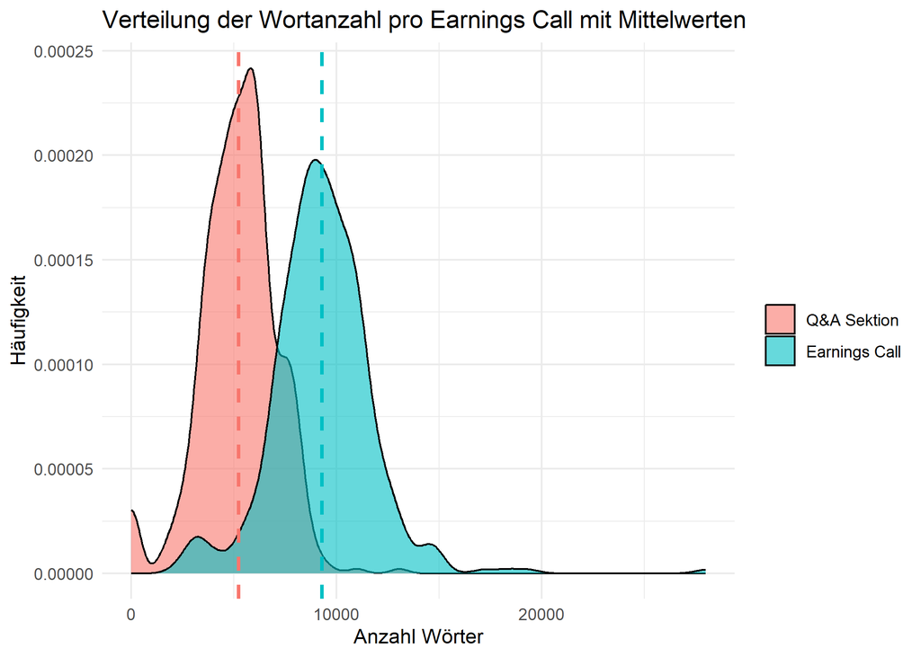

**Beschreibung**  
Die Grafik zeigt die Verteilung der Anzahl der Worte in Earnings Calls (blau) und der Q&A Sektion (rosa). Zudem werden die Mittelwerte beider Verteilungen ausgegeben. Die Verteilung der gesamten Earnings Calls hat einen klaren Hauptgipfel bei 8000-9000 Wörter. Der Mittelwert liegt bei 9000 Wörtern und die Verteilung ist rechtsschief mit wenigen Calls die deutlich länger sind. Die Verteilung der Q&A Sektionen hat einen kleineren Peak bei 0-1000 Wörtern und einen größeren bei 5000-6000 Wörtern. Der Mittelwert liegt bei 5000 Wörtern und damit beim größeren Peak. Es gibt nur sehr weniger sehr viel längere Q&A Sektionen. Die vielen kurzen Q&A Sektionen können durch entweder nicht abgehaltene Q&A Sektionen oder nur wenige zugelassene Fragen erklärt werden. Wie die Verteilungen zeigen und auch die Mittelwerte nahelegen, macht die Q&A Sektion im Durchschnitt ca. die Hällte der gesamten Worte aus.

## Themenkategorien und Sentiment-Scores

Nachdem Sie nun die Earnings Conference Calls in R eingelesen und einen ersten Eindruck von deren Inhalt erhalten haben sollten Sie diese mit einem LLM (konkret mit Google Gemini) analysieren. Dafür sollten Sie einen Zero-Shot Prompt erstellen und mit Hilfe dieses Prompts die Aussage der Q&A Sektionen der Earnings Conference Calls analysieren.

9. Entwickeln Sie einen Zero-Shot Prompt für ein Large Language Model (LLM), der Earnings Conference Call Transcripts analysiert und strukturierte Sentiment-Bewertungen ausgibt. Bitte beachten Sie dabei folgende Punkte:

Zielkategorien:

- Unternehmensperformance (Finanzlage, Wachstumschancen, Unternehmensrisiken)
- Marktumfeld (Branche, Wettbewerb, externe Faktoren)

Output-Format:

- JSON-Struktur mit Sentiment-Scores von -1 (sehr negativ) bis +1 (sehr positiv)
- Keine zusätzlichen Erklärungen oder Markdown-Formatierung

Sie sollten in ihrem Prompt nach einem JSON Output verlangen (strukturiertes Format), welchen Sie mit dem Paket `jsonlite` gut in R verarbeiten können.

*Hinweis 1:* Im Anhang ist eine Erklärung für die Unterschiede zwischen einem Zero-Shot Prompt, einem One-Shot Prompt und einem Few-Shot Prompt

*Hinweis 2:* Wir haben Ihnen ein [Tutorial zusammengestellt](https://projektkurs-data-science-ulm2425.netlify.app/tutorials/zero-prompting), welches das Prompting an einem Beispiel zeigt.

Analysiere das folgende Earnings Call Transkript und gib ausschließlich eine gültige JSON-Antwort zurück. Untermenmensperformance bezieht Finanzlage, Wachstumschancen und Unternehmensrisiken ein. Marktumfeld ist für Branche, Wettbewerb und externe Faktoren.  
Die JSON-Struktur soll wie folgt aussehen:  
{  
“filename1”: {  
“Unternehmensperformance”: <Sentiment-Score von -1 (sehr negativ) bis +1 (sehr positiv)>,  
“filename”: <Sentiment-Score von -1 (sehr negativ) bis +1 (sehr positiv)>  
},  
“filename2”: {  
“Unternehmensperformance”: <Sentiment-Score von -1 (sehr negativ) bis +1 (sehr positiv)>,  
“Marktumfeld”: <Sentiment-Score von -1 (sehr negativ) bis +1 (sehr positiv)>  
},  
…  
}

Transkript zu filename1:  
…  
Transkript zu filename2:  
…

10. Im nächsten Schritt sollten Sie sich in das Paket [`ellmer`](https://ellmer.tidyverse.org/) einarbeiten. Durch `ellmer` erhalten Sie Zugriff auf alle gängigen LLMs mittels R über einen API Zugang. Wir haben ihnen für dieses Projekt ein Google Konto pro Gruppe erstellt und den API Schlüssel für jede Gruppe in das dazugehörige Repo (Readme) gepushed.
- Lesen Sie sich in das [`ellmer`](https://ellmer.tidyverse.org/) Paket ein und wie Sie den API Schlüssel für Google Gemini in ihrer .Renviron Datei hinterlegen können
- Untersuchen Sie die unterschiedlichen Modelle, die Google zur Verfügung stellt und deren Ratelimits: https://ai.google.dev/gemini-api/docs/models?hl=de

Bitte beantworten Sie folgende Fragen:

- Was sind die Vorteile/Nachteile der einzelnen Google Modelle?
- Welches (kostenlose) Modell würden Sie für ihre aktuellen Analysen bevorzugt einsetzen? Begründen Sie!
- Welche Möglichkeiten haben Sie, nicht in die Ratelimits zu kommen?
- In `ellmer` können Sie mittels dem [`params()`](https://www.tidyverse.org/blog/2025/05/ellmer-0-2-0/#parameters) Parameter auch die Temperatur ihres Modells einstellen. Was ist mit der Temperatur gemeint und was sind die Vorteile/Nachteile einer niedrigen Temperatur?

**Was sind die Vorteile/Nachteile der einzelnen Google Modelle?**  
2.5 Pro:  
Gemini 2.5 Pro ist das leistungsstärkste Denkmodell und optimal für komplexe Programmierungen, Logik und multimodales Verständnis. Es kann schwierige Probleme angehen und große Datenbanken analysieren. Die Live API wird jedoch noch nicht unterstützt.

2.5 Flash:  
Gemini 2.5 Flash ist am besten für Aufgaben mit niedriger Latenz und großem Volumen geeignet. Es kann große Datenmengen verarbeiten und über diese Nachdenken sowie für agentische Anwendungsfälle verwendet werden. Zudem unterstützt es Live API Zugriff. Es ist schlechter für komplexe Logikprobleme oder multimodales Verständnis geeignet als Gemini 2.5 Pro.

2.5 Flash-Lite:  
Gemini 2.5 Flash-Lite ist am besten für Anwendungsfälle in Echtzeit mit niedriger Latenz und hohem Durchsatz geeignet. Es ist ähnlich wie Gemini 2.5 Flash weniger gut für komplexe Logikprobleme geeignet sticht jedoch mit hohem Durchsatz hervor. Die Live API ist in der Vorabversion noch nicht unterstützt.

**Welches Modell werden wir verwenden?**  
Da wir von der API gebrauch machen möchten sowie große Volumen an Daten übertragen und analysieren möchten ist Gemini 2.5 Flash am besten geeignet. Die Verwendung des leistungsstärkeren Gemini 2.5 Pro ist nicht notwendig, da es sich bei der Analyse lediglich um die Einordnung von Textdokumenten und nicht um komplexe logische Probleme handelt. Die Fähigkeiten von Gemini 2.5 Flash über große Datenmengen nachzudenken und diese einzuordnen sind für unsere Analyse ideal.

**Welche Möglichkeiten haben wir, nicht in die Ratelimits zu kommen?**  
Um nicht in die Ratelimits zu geraten, können mehrer Maßnahmen ergriffen werden. Zum einen können mehrer Dokumente gleichzeitig hochgeladen werden. Diese Möglichkeit wurde bereits beim Erstellen des Prompts berücksichtigt. Des Weiteren können kleine zeitliche Abstände zwischen dem Hochladen der Dokumente verwendet werden. Dies kann helfen, Beschränkungen im Upload pro Minute einzuhalten.

**Was ist mit der Temperatur gemeint und was sind die Vorteile/Nachteile einer niedrigen Temperatur?**  
Temperatur ist ein Parameter, der die Zufälligkeit des Ergebnisses bestimmt. Eine niedrige Temperatur sorgt dabei für ein deterministisches Ergebnis und eine hohe Temperatur für ein zufälliges. Eine niedrige Temperatur ist für diese Analyse gut geeignet, da sie durch die deterministischen Antworten immer ähnliche Ergebnisse produziert. Dies sorgt für die Reproduzierbarkeit der Analysen. Nachteilig ist, dass die Antworten für komplexere Probleme weniger kreativ ausfallen.

11. Nutzen Sie ihren in Aufgabe 9 erstellten Prompt mit dem `ellmer` Paket und ihrem Google API-Key um alle 431 Earnings Conference Call Transkripte zu analysieren. Nutzen Sie für ihre Analyse das Modell Google Gemini 2.0-flash oder Google Gemini 2.5-flash.

Speichern Sie die Ergebnisse ihrer Analyse in einem strukturierten Tibble ab. Anschließend sollten Sie den Datensatz auch unter `data/sentiment.Rds` abspeichern.

Stellen Sie ihre Ergebnisse in einer Tabelle dar und beschreiben diese kurz:

- Wie ist der Mittelwert, Standardabweichung und Median der Einschätzung bezüglich Unternehmensperformance und Marktumfeld in ihren Earnings Conference Calls?

*Hinweis 1:* Achten Sie darauf nicht bei jedem Knitten die Analyse neu zu starten, sondern setzen Sie den Chunk dieser Aufgabe auf `eval = FALSE` und lassen Sie die Analyse nur einmal durchlaufen und speichern Sie die Ergebnisse ab (und laden diese später um damit weiterarbeiten zu können)

*Hinweis 2:* Achten Sie auf ihre Ratelimits und beanspruchen Sie den API Zugriff nicht zu stark, z.B. durch den Einbau von “sleep”-Zeiten in ihrem Code

| Statistik zur Sentiment Analyse Variable | Statistik zur Sentiment Analyse Mittelwert | Statistik zur Sentiment Analyse Median | Statistik zur Sentiment Analyse Standardabweichung |
| --- | --- | --- | --- |
| Marktumfeld | 0.33 | 0.3 | 0.37 |
| Unternehmensperformance | 0.65 | 0.8 | 0.32 |

**Beschreibung**  
Bei der Variable Marktumfeld liegt der Median (0.3) etwas niedriger als der Mittelwert (0.33). Daraus lässt sich schließen, dass es etwas weniger große als kleine Werte gibt. Die Werte sind jedoch beide positiv, dies deutet auf ein generell positives Marktumfeld hin. Die Standardabweichung ist größer als der Mittelwert. Dies lässt auf eine breite Streuung der Werte schließen. Die Variable Unternehmensperformance hat einen deutlich größeren Mittelwert (0.65) als die Variable Marktumfeld (0.33). Daraus lässt sich schließen, dass die Erwartung der Unternehmensperformance meist stark postiv dargestellt ist, während das Marktumfeld manchmal als schwieriger dargestellt wird. Für dies könnte ein systematischer Bias verantwortlich sein, da die Manager eines Untenehmens dieses tendenzielle positiver präsentieren möchten. Der Median ist mit 0.8 größer als der Mittelwert (0.65). Dabei ist der Abstand größer als beim Marktumfeld. Dies zeigt, dass mehr Werte über dem Mittelwert liegen. Die Standardabweichung ist ähnlich zum Marktumfeld und halb so groß wie der Mittelwert. Dies deutet wieder auf eine recht breite Streuung hin.

Sie haben in der vorherigen Aufgabe die Stimmung bezüglich der Kategorien Unternehmensperformance und Marktperformance in den Earnings Conference Calls bestimmt. Eine Frage wäre, ob sich diese Stimmung über die Zeit hinweg verändert hat. In der folgenden Aufgabe sollen Sie sich die durchschnittliche Stimmung in diesen zwei Kategorien für die einzelnen Jahre in ihrem Datensatz näher anschauen.

12. Erstellen Sie eine geeignete Grafik um die Stimmung *aller Earnings Conference Calls eines Jahres* zu visualisieren. Tragen Sie separat die Stimmung bezüglich Unternehmensperformance und Marktumfeld ab.

Beschreiben Sie ihre Grafik.

Interpretieren Sie diese Grafik, insbesondere im Hinblick auf die gesamtwirtschaftlichen Ereignisse der letzten fünf Jahre. Hätten Sie die Ergebnisse in dieser Art erwartet?

*Hinweis:* Sie sollten sich hier eine sinnvolle Grafik überlegen, welche die Stimmungslage über die Zeit gut darstellt.

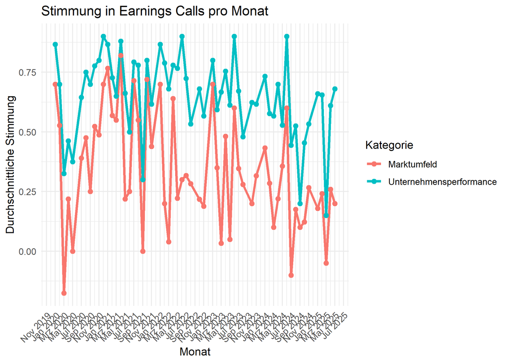

**Beschreibung:**  
Die Grafik zeigt die zeitliche Entwicklung der durchschnittlichen Stimmung bezüglich des Marktumfeldes und der Unternehmensperformacen von November 2019 bis Juli 2025. In Türkis ist die durchschnittliche Stimmung bezüglich der Unternehmensperformance aller Earnings Calls in diesem Monat und in Rot die des Marktumfeldes zu sehen. Die y-Achse zeigt dabei die durschschnittliche Stimmung und die x-Achse den Monat.

**Interpretation:**  
Auffällig ist, dass die Unternehmensperformance stets positiv und besser als die gesamtwirschaftliche Situation dargestellt ist. Wie bereits beschrieben, kann sich dies aus dem Interesse der Manager, ihr Unternehmen als positiv darzustellen, ableiten lassen.  
2020 (Pandemiebeginn):  
Das Marktumfeld nimmt Anfang des Jahres den kleinsten Werte überhaupt an, zum Ende steigt die Stimmung wieder. Begründet werden kann dies durch Unsicherheiten bezüglich Lockdowns und Lieferkerttenstörungen. Die Unternehmensperformance schneidet nicht so schlecht ab und erholt sich ebenfalls zum Ende des Jahres wieder. Viele Unternehmen werden digitaler und erhalten Hilfe vom Staat.  
2021:  
Die Erholung der Stimmung bezüglich des Martkumfeldes setzt sich fort. Es bricht allerdings zum Herbst wieder ein, wahrscheinlich aus Sorge vor weiteren Corona Beschränkungen im Winter. Die Stimmung bezüglich der Unternehmensperformance folgt dem des Marktumfeldes. Zum Ende des Jahres haben sich beide Werte jedoch wieder erholt.  
2022 (Ukrainekrieg):  
Die Stimmung des Marktumfeldes sinkt merklich ab und verharrt nach kurzem Ausschlag nach oben auf niedrigem Niveau. Grund dafür ist der Beginn des Ukrainekriegs und die darauf folgende Energiekriese. Der kurze Ausschlag nach oben lässt sich durch mögliche Hoffnungen auf ein schnelles Ende erklären. Die Unternehmensperformance wird durch den Ukrainekrieg nicht so stark in Mitleidenschaft gezogen. Diese bricht nur zum Ende des Sommers mit Blick auf eine Energiekriese im Winter ein. Die Geschäfte der meisten Unternehmen werden ansonsten kaum negativ durch den Ukrainekrieg beeinflusst. 2023 & 2024:  
Die Stimmung bezüglich des Marktumfeldes bleibt auf geringem Niveau. Große Volatilität spricht dabei für Unsicherheiten, examplarisch sind die Zinswende sowie andauernde Rezessionsängste zu nennen. Die Stimmung der Unternehemsperformance ist weiterhin höher als die des Marktumfeldes und ebenfalls volatil. Marktumfeld und Unternehmensperformance verhalten sich sehr ähnlich.  
2025:  
Bis jetzt ist das Jahr 2025 ebenfalls volatil. Das Marktumfeld verharrt auf niedrigem Niveau während die Stimmung der Unternehmen wieder etwas positiver ist. Die Volatilität könnte hierbei mit den Hoffnungen und Dämpfern rund um die Amtseinführung der neuen Bundesregierung erklärt werden.

**Erwartung:**  
Im großen und ganzen ist dieser Verlauf zu erwarten. Dies gilt für die bessere Einschätzung der Unternehmen zu eigene Lage sowie die starke Volatilität rund um die Krisen der vergangenen Jahre.

# Eventstudie

Um zu evaluieren, ob die Earnings Conference Calls tatsächlich einen Einfluss auf die Aktienkurse der einzelnen Unternehmen hatten können Sie eine sogenannte Eventstudie durchführen, welche Sie bereits in Aufgabe 1 kennen gelernt haben. Bei einer Eventstudie betrachten Sie nur die Zeit (bei uns die Tage) unmittelbar vor oder nach einem Event. In diesem Projekt ist ein Event ein Earnings Conference Call des jeweiligen Unternehmens. Sie sollen in diesem Projekt herausfinden, wie sich über alle Unternehmen hinweg die Earnings Conference Calls auf die Aktienrenditen auswirken.

13. Verbinden Sie den Datensatz über die *Stimmung der Earnings Conference Calls (sentiment.Rds)* zu den einzelnen Unternehmen mit den *abnormalen Renditen* und speichern diesen Datensatz als `gesamtdatensatz` in R ab. Sie können das RIC-Kürzel und Datum für den Join verwenden. Sollte der Earnings Conference Call an keinem Handelstag stattgefunden haben, so joinen Sie bitte mit dem darauffolgenden Handelstag.
- Für die Tage an denen ein Earnings Conference Call stattgefunden hat sollten Sie eine Variable `event` generieren, welche an dem Tag des Calls gleich 0 ist.
- Für die Tage vor dem Earnings Conference Call (Event) sollte die Variable `event` rückwärts zählen (bis zu -5). Für alle Tage nach dem Event sollte die Variable `event` fortgeführt werden (bis +5).
- Erstellen Sie eine Variable `ar_505`, welche die *abnormalen Rendite* von Tag -5 bis +5 **fortlaufend** aufsummiert
- Erstellen Sie eine Variable `car_101`, welche die kumulierte abnormale Rendite im Zeitraum -1 bis +1 um das Event beinhaltet
- Erstellen Sie weiterhin diese sechs neuen Variablen:
  - `negativ_firm` = Wenn die Unternehmensperformance als negativ eingeschätzt wird
  - `neutral_firm` = Wenn die Unternehmensperformance als neutral eingeschätzt wird
  - `positiv_firm` = Wenn die Unternehmensperformance als positiv eingeschätzt wird
  - `negativ_market` = Wenn die Marktperformance als negativ eingeschätzt wird
  - `neutral_market` = Wenn die Marktperformance als neutral eingeschätzt wird
  - `positiv_market` = Wenn die Marktperformance als positiv eingeschätzt wird
- Erstellen Sie Dummy Variablen, die 1 sind für ein bestimmtes Jahr. Bspw. eine Dummyvariable die 2020 heißt und für alle Beobachtungen im Jahr 2020 sollte diese Variable 1 sein, 0 sonst. Tun Sie dies für alle Jahre in ihrem Datensatz

*Hinweis:* Die Funktion cumsum() könnte für diese Aufgabe hilfreich sein

14. Erstellen Sie je ein Liniendiagramm für die von ihnen betrachteten Unternehmen: Eines für die Stimmung bezüglich der Unternehmensperformance und eines bezüglich der Marktperformance.

Sie sollten in ihren Grafiken die kumulierten Renditen im Zeitraum [-5,5] Tage um einen Earnings Conference Call darstellen. - Die Variable “Event” sollte die Tage vor und nach dem Earnings Conference Call enthalten ([-5,5]) und auf der x-Achse dargestellt werden - Die Variable `ar_505` sollte die durchschnittliche kumulierte abnormale Rendite für den jeweiligen Tag auf der y-Achse abtragen (für alle Unternehmen in ihrem Datensatz) - In jeder Grafik sollten Sie eine extra Linie zeichnen für Earnings Conference Calls mit einer positiven/negativen und neutralen Stimmung und deren Einfluss auf den Aktienmarkt

Beschreiben und interpretieren Sie ihre Grafik. Gehen Sie hierbei insbesondere darauf ein, welche Erwartungen Sie auf der Basis ihrer Lektüre aus Aufgabe 1 hatten und in wie weit diese Erwartungen sich erfüllt haben.

*Hinweis:* In diesen Grafiken stellen Sie nicht jedes Event (d.h. die Auswirkungen eines jeden Earnings Conference Calls) einzeln dar, sondern gesamt für alle Earnings Conference Calls.

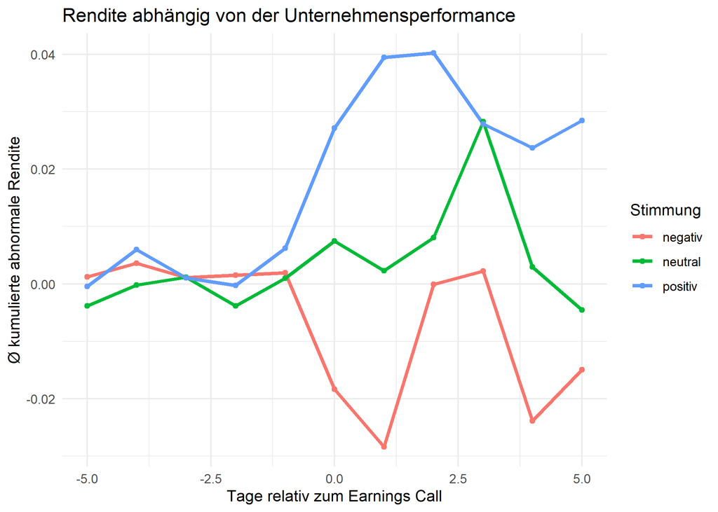

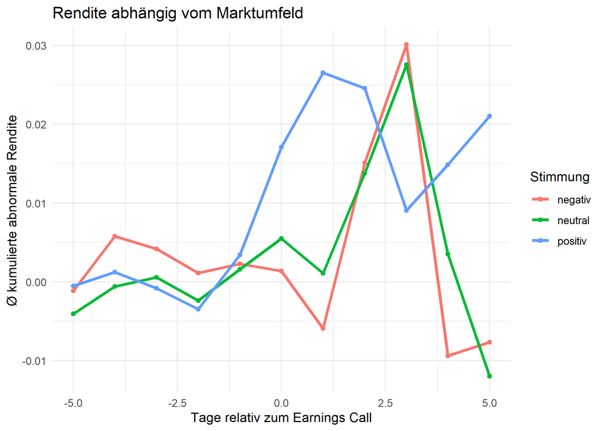

**Interpretation:**  
Aus der Grafik zur Unternehmensperformance kann man einen Zusammenhang zwischen der festgestellten Stimmung bezüglich des Unternehmens im Earnings Call und der kumulierten abnormalen Rendite ableiten. Der Zusammenhang scheint dabei für alle 3 Stimmungen gut zu funktionieren. Dies entspricht den Erwartungen nach Aufgabe 1, da sich die Veränderung erst ab dem Earnings Call bemerkbar macht und dann zu den Gruppierungen passt. In der Grafik zum Marktumfeld ist der Zusammenhang nicht so eindeutig. Für eine positive Stimmung kann weiterhin ein positiver Zusammenhang festegestellt werden, jedoch verhält sich die negative Stimmung gleich zur neutralen und bricht erst einen Tag nach dem Earnings Call ein. Der starke Anstieg 2 bis 3 Tage nach dem Call entspricht ebenfalls nicht den Erwartungen, tritt jedoch bei der Unternehmensperformance in kleiner auch auf. Es ist möglich, dass die Stimmung bezüglich des Marktumfeldes kein besonders guter Indikator für negative Rendite ist. Da dies bezüglich der Unternehmensperformance besser funktioniert, kann angenommen werden, dass dies kein Fehler in der Vorhersage der Rendite ohne Eintritt des Ereignisses ist. Nach Aufgabe 1 folgt, dass dieser Indikator somit keinen gut messbaren Effekt für negative Rendite hat.

**Fazit:**  
Die Stimmung bezüglich der Unternehmensperformance scheint ein guter Indikator für die Rendite ab dem Earnings Call zu sein. Die Stimmung bezüglich des Marktumfeldes scheint jedoch nur für die positive Stimmung einen Zusammenhang zu haben.

# Regressionen

Sie haben bisher den Einfluss der Earnings Conference Calls auf die Aktienrendite der größten europäischen Unternehmen im Technologie-Sektor visuell betrachtet. Im letzten Abschnitt dieser Projektarbeit analysieren Sie ihre Daten mittels linearer Regressionen.

15. In dieser Aufgabe sollten Sie zwei Regressionen erstellen:

Regressieren Sie die kumulierten abnormalen Renditen um das Event `car_101` auf die Dummyvariablen

- `negativ_firm` und `negativ_market` in der ersten Regression und
- `positiv_firm` und `positiv_market` in der zweiten Regression.

Diese Dummyvariablen geben die Stimmung in den Earnings-Conference Calls wieder.

Beschreibung und interpretieren Sie ihre Regressionsergebnisse und gehen Sie dabei auch auf folgende Fragen ein:

- Was ist die Vergleichsgruppe in den beiden Regressionen?
- Was sind die Voraussetzungen für eine kausale Interpretation der Koeffizienten. Sind diese ihrer Meinung nach gegeben?

|  | Negative Stimmung | Positive Stimmung |
| --- | --- | --- |
| Konstante | 0.018*** | -0.006+ |
|  | (<0.001) | (0.083) |
| Negative Firmenstimmung | -0.043*** |  |
|  | (<0.001) |  |
| Negative Marktstimmung | -0.001 |  |
|  | (0.900) |  |
| Positive Firmenstimmung |  | 0.026*** |
|  |  | (<0.001) |
| Positive Marktstimmung |  | 0.020*** |
|  |  | (<0.001) |
| Num.Obs. | 1163 | 1163 |
| R2 | 0.030 | 0.040 |
| R2 Adj. | 0.029 | 0.038 |

**Beschreibung:**

Die Regressionsergebnisse zeigen den Zusammenhang zwischen der Stimmung in Earnings Calls und den kumulierten abnormalen Renditen im Zeitfenster von einem Tag vor bis einem Tag nach dem Event. Die erste Regression untersucht den Einfluss negativer Stimmung in Firmen und auf dem Markt, während die zweite Regression positive Stimmung betrachtet. Negative Äußerungen zur Unternehmensperformance haben einen signifikant negativen Effekt auf die Renditen. Der Koeffizient von -0,043 ist auf dem 1%-Niveau signifikant und deutet darauf hin, dass pessimistische Aussagen des Managements zu durchschnittlich 4,3 Prozentpunkten niedrigeren abnormalen Renditen führen. Im Gegensatz dazu zeigt die positive Firmenstimmung einen signifikant positiven Effekt. Hier führt ein optimistischer Ton zu einem Anstieg der Renditen um durchschnittlich 2,6 Prozentpunkte. Die Stimmung zum Marktumfeld weist ein anderes Muster auf. Während negative Marktkommentare keinen signifikanten Einfluss haben, geht eine positive Markteinschätzung mit einem leichten, aber signifikanten Renditeanstieg von 2,0 Prozentpunkten einher. Die unterschiedliche Reaktion deutet darauf hin, dass Investoren unternehmensspezifische Aussagen stärker gewichten als allgemeine Marktkommentare. Die Konstante in der ersten Regression ist positiv und signifikant, was auf leicht höhere Renditen in neutralen Situationen hindeutet. In der zweiten Regression ist die Konstante negativ, was bedeutet, dass ohne positive Signale die Renditen tendenziell leicht sinken. Die erklärte Varianz (R²) liegt in beiden Modellen bei etwa 3 bis 4 Prozent, was typisch für Eventstudien ist und zeigt, dass weitere Faktoren die Renditen beeinflussen.

**Interpretation:**

Die Ergebnisse zeigen charakteristische Muster in der Reaktion der Märkte auf unterschiedliche Stimmungsäußerungen in Earnings Calls. Besonders auffällig ist der stärkere Effekt negativer Unternehmensaussagen (-0,043) im Vergleich zu positiven (0,026). Dies könnte darauf hindeuten, dass Investoren kritische Bewertungen der eigenen Geschäftslage durch das Management besonders ernst nehmen. Die Ergebnisse zur Marktstimmung zeigen ein anderes Bild: Während positive Markteinschätzungen einen messbaren Einfluss haben (0,020), bleiben negative ohne signifikante Wirkung. Eine mögliche Erklärung wäre, dass Investoren allgemeine Marktkommentare als weniger aussagekräftig einstufen als unternehmensspezifische Aussagen. Die Modellgüte (R² zwischen 0,03 und 0,04) entspricht den Erwartungen für Eventstudien dieser Art. Sie bestätigt, dass die Stimmung in Earnings Calls zwar einen erkennbaren, aber begrenzten Einfluss auf die Renditen hat.

In der ersten Regression (negative Stimmung) werden Unternehmen mit negativen Aussagen gegen alle anderen Fälle verglichen (sowohl neutrale als auch positive Statements). Die positive Konstante (0,018) zeigt, dass diese Vergleichsgruppe im Schnitt leicht höhere Renditen erzielt. Für die zweite Regression (positive Stimmung) gilt das umgekehrte Prinzip. Hier werden positive Aussagen mit allen nicht-positiven Fällen (neutral und negativ) kontrastiert. Die negative Konstante (-0,006) weist darauf hin, dass diese gemischte Gruppe tendenziell leicht unterdurchschnittliche Renditen aufweist.

Für eine kausale Interpretation der Ergebnisse müssten mehrere Annahmen erfüllt sein. Zentral ist die Frage, ob die Stimmungsäußerungen tatsächlich unabhängig von anderen Renditeeinflussfaktoren sind. In der Praxis ist dies schwer nachzuweisen, da Managementaussagen oft auf denselben Fundamentaldaten basieren, die auch die Aktienkurse beeinflussen. Ohne zusätzliche Kontrollvariablen oder experimentelle Designs bleibt die Interpretation daher vorwiegend korrelativ. Dennoch bieten die Ergebnisse wichtige Hinweise darauf, wie der Markt verschiedene Arten von Informationen aus Earnings Calls verarbeitet.

16. In ihrer deskriptiven Analyse haben Sie bereits gesehen, dass die Unternehmen, die Sie in diesem Projekt betrachten, alle unterschiedlich groß sind. Weiterhin haben Sie gesehen, dass es ein unterschiedliches Stimmungsbild in den Calls über die einzelnen Jahre hinweg gibt. Dafür möchten Sie in ihren Regressionen nun kontrollieren.
    1. Regressieren Sie die `car_101` auf die Variablen *negativ_firm* und *negativ_market* und kontrollieren Sie auf die Größe des jeweiligen Unternehmens, indem Sie die Variable *Total_Assets* in ihre Regression aufnehmen
    2. Fügen Sie in einer zweiten Analyse zusätzlich zu den Variablen aus der 1. Regression auch noch Dummyvariablen für die Jahre in dem das Event stattgefunden hat ihrer Regression hinzu.
    3. Führen Sie die Regressionen aus 1. und 2. auch für die Variablen *positiv_firm* und *positiv_market* anstatt *negativ_firm* und *negativ_market* durch, sodass Sie am Ende 4 Regressionen haben

Beschreiben und interpretieren Sie ihre Ergebnisse im Hinblick auf die Größe der Koeffizienten und deren Signifikanz. Gehen Sie insbesondere auf folgende Fragen ein:

- Warum sollte ihre Regression nicht fünf Dummyvariablen, je eine für jedes Jahr, sondern nur vier beinhalten?
- Verändert sich durch die Dummyvariablen der Koeffizient von *negativ_firm* und *negativ_market* bzw. *positiv_firm* und *positiv_market*?
- Hätten Sie eine Veränderung des Koeffizienten von *negativ_firm*, *negativ_market*, *positiv_firm* oder *positiv_market* erwartet? Begründen Sie ihre Antwort mit ihren deskriptiven Analysen.

|  | Negativ: ohne Jahresdummies | Negativ: mit Jahresdummies | Positiv: ohne Jahresdummies | Positiv: mit Jahresdummies |
| --- | --- | --- | --- | --- |
| Konstante | -1.209+ | -2.471* | -1.640* | -2.315+ |
|  | (0.072) | (0.049) | (0.017) | (0.062) |
| Negative Firmenstimmung | -0.044*** | -0.042*** |  |  |
|  | (<0.001) | (<0.001) |  |  |
| Negative Marktstimmung | -0.003 | -0.003 |  |  |
|  | (0.705) | (0.745) |  |  |
| Positive Firmenstimmung |  |  | 0.025*** | 0.026*** |
|  |  |  | (<0.001) | (<0.001) |
| Positive Marktstimmung |  |  | 0.024*** | 0.023*** |
|  |  |  | (<0.001) | (<0.001) |
| Log(Total Assets) | 0.085+ | 0.172* | 0.113* | 0.160+ |
|  | (0.068) | (0.047) | (0.017) | (0.063) |
| Jahr 2021 |  | 0.000 |  | -0.008 |
|  |  | (0.971) |  | (0.373) |
| Jahr 2022 |  | -0.001 |  | -0.003 |
|  |  | (0.891) |  | (0.749) |
| Jahr 2023 |  | 0.002 |  | 0.003 |
|  |  | (0.869) |  | (0.756) |
| Jahr 2024 |  | -0.028* |  | -0.026* |
|  |  | (0.028) |  | (0.039) |
| Jahr 2025 |  | 0.007 |  | 0.012 |
|  |  | (0.716) |  | (0.504) |
| Num.Obs. | 1163 | 1163 | 1163 | 1163 |
| R2 | 0.033 | 0.044 | 0.044 | 0.057 |
| R2 Adj. | 0.030 | 0.038 | 0.042 | 0.050 |

**Interpretation:**

Die Einführung der Jahresdummies verändert die Koeffizienten der Stimmungsvariablen kaum. Dies ist ein wichtiger Hinweis darauf, dass der Einfluss der Stimmung auf die Renditen robust ist und nicht durch jahresspezifische Effekte überlagert wird. Die Stabilität der Koeffizienten spricht für die Reliabilität der gefundenen Zusammenhänge. Sie deutet darauf hin, dass die Stimmung in Earnings-Calls einen eigenständigen Erklärungsbeitrag für Renditeentwicklungen liefert.

17. Zum Abschluss sollten Sie dazu Stellung beziehen, in wie weit die Erkenntnisse aus diesem Projekt für eine Handelsstrategie genutzt werden könnten. Konkret sollten Sie erläutern ob es sinnvoll ist eine Unternehmensaktie bei einem negativem Sentiment im Earnings Conference Call automatisiert zu verkaufen.

Beziehen Sie sich in ihrer Argumentation insbesondere auf:

- Zeitliche Aspekte (Wann reagiert der Markt vs. wann liegt das Sentiment vor?)
- Methodische Limitationen Ihrer Event Study
- Unsicherheiten bei der LLM-Sentiment-Analyse

Begründen Sie jeden Kritikpunkt konkret mit Bezug auf Ihre Projektarbeit und schließen Sie mit einer realistischen Einschätzung ab: Wofür könnten Ihre Ergebnisse trotz dieser Limitationen in der Praxis dennoch wertvoll sein?

Die Erkenntnisse aus der Projektarbeit zeigen einen klaren Zusammenhang zwischen der mittels LLM analysierten Stimmung in Earnings Conference Calls und den abnormalen Renditen der Unternehmen des Euro Stoxx 600 Technology Index. Die Regressionsanalysen aus Aufgabe 15 und 16 belegen, dass insbesondere negative Äußerungen zur Unternehmensperformance (Koeffizient von -0.043) zu signifikanten Renditeeinbrüchen führen, während positive Aussagen (Koeffizient 0.026) leicht steigende Renditen bewirken. Die Event-Study-Grafiken aus Aufgabe 14 verdeutlichen zudem, dass diese Effekte unmittelbar nach dem Earnings Call eintreten. Trotz dieser klaren Muster ergeben sich bei der Umsetzung als Handelsstrategie mehrere praktische Herausforderungen.

Die kumulierten abnormalen Renditen im 3-Tages-Fenster (-1 bis +1) zeigen, dass der Markt bereits am Tag des Calls und kurz danach reagiert. Dies wird besonders deutlich in der Grafik zur Unternehmensperformance, wo die Linien für positive/negative Stimmung sich direkt nach dem Event (t=0) deutlich trennen. Für eine profitable Strategie müssten jedoch mehrere zeitkritische Schritte absolviert werden. Selbst bei Automatisierung aller Schritte wäre die Verzögerung zu groß, um die initiale Marktreaktion (die sich oft innerhalb von Minuten vollzieht) auszunutzen.

Eine vollautomatisierte Handelsstrategie, die ausschließlich auf unserer LLM-basierten Sentiment-Analyse beruht, erscheint aufgrund der zeitlichen Verzögerungen, methodischen Unsicherheiten der Event Study und Klassifikationslimitationen nicht praktikabel. Die Ergebnisse sind jedoch als ergänzendes Werkzeug in einem breiteren Analyserahmen nützlich und können dazu beitragen, Marktreaktionen besser zu verstehen und zu antizipieren.

# Zusatzaufgabe

In Aufgabe 6 berechnen Sie die *abnormalen Renditen* der einzelnen von ihnen betrachteten Unternehmen. Nun könnte es allerdings sein, dass es nicht ausreicht den Marktindex einfach von der Aktienrendite abzuziehen um für die erwartete Performance der Aktie zu kontrollieren. Potentiell wäre es besser für die durchschnittliche Performance der Aktie zu kontrollieren in der keine Events stattfinden.

Sie können eine solche durchschnittliche Performance schätzen. Dazu sollten Sie eine Schätzperiode *vor* dem Event definieren. Diese Periode sollen Sie auf 120 bis 10 Handelstage vor dem Event festlegen. Die durchschnittliche Rendite der Einzelaktie sollten Sie in dieser Periode auf die Marktrendite regressieren. Dieses Modell wird `Risk-adjusted returns model` in Huntington-Klein (2021) genannt:

$$\begin{equation}
\hat{Rendite}_{i,t} = \alpha + \beta Rendite_{m,t}
\end{equation}$$

Anschließend nutzen Sie die vorhergesagten Werte und ziehen diese in der Eventphase von der Rendite der Einzelaktie ab.

18. Erstellen Sie die kumulierten abnormalen Renditen im Zeitraum -5 bis +5 mit Hilfe ihres Risk-adjusted returns model neu (und nennen diese `mar_505`). Erstellen Sie die kumulierten abnormalen Renditen im Zeitraum -1 bis +1 um das Event mit Hilfe ihres Risk-adjusted returns model neu (und nennen die Variable `cmar_101`) und vergleichen die Werte in einer geeigneten Grafik mit den Ergebnissen aus dem market-adjusted returns model (`car_101`).
- Gibt es hier große Unterschiede?
- Warum gibt es diese Unterschiede, oder warum sehen Sie nur geringe Unterschiede?

[figure not shown]

19. Erstellen Sie die Grafik von Aufgabe 12 neu.

Beschreiben und interpretieren Sie ihre Grafik. Gehen Sie auch auf folgende Fragen ein:

- Könnte es zu Problemen führen, wenn in der Schätzperiode vor dem Event ein weiterer Earnings-Conference Call enthalten ist?
  - Warum könnte dies ein Problem sein, oder warum nicht?

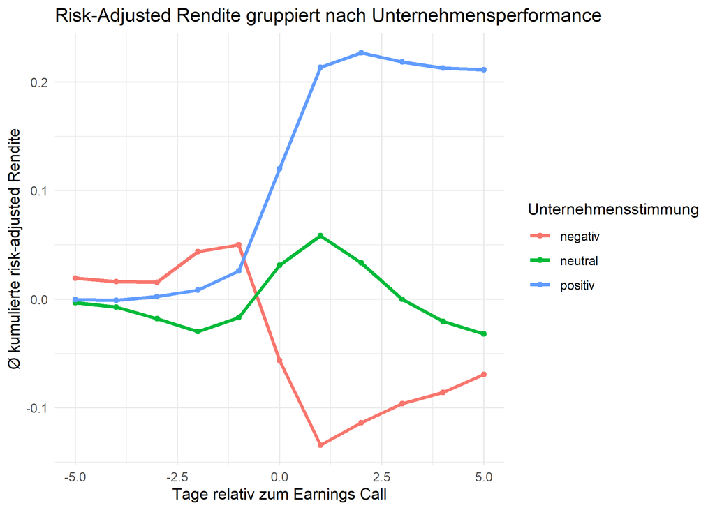

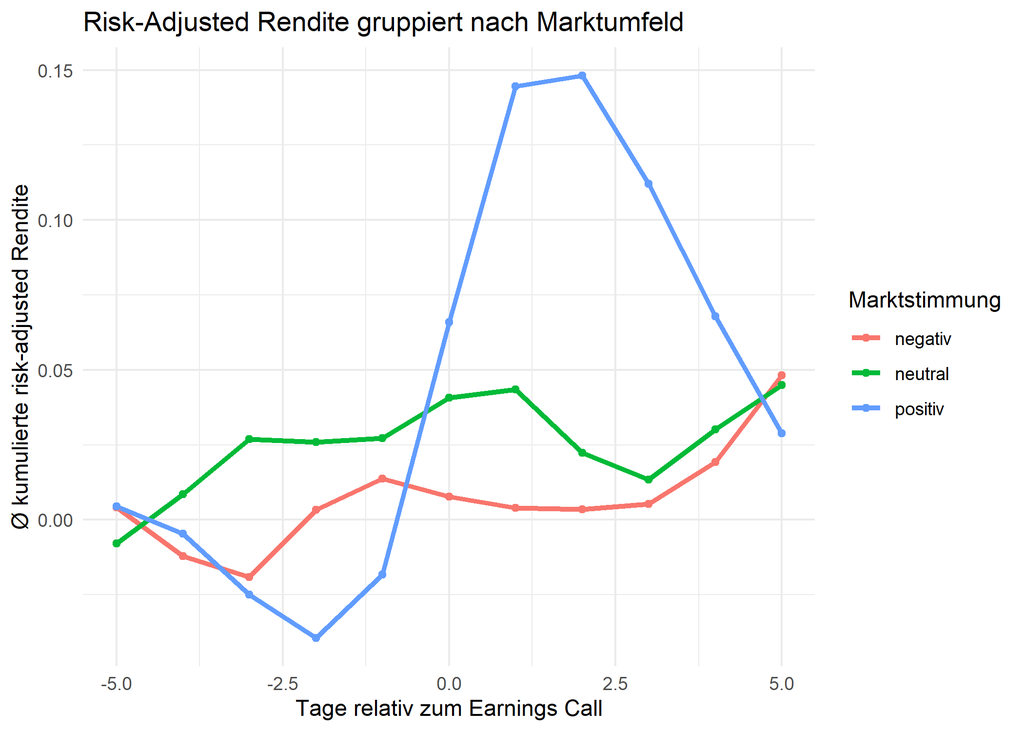

**Interpretation:**

Ein zweiter Earnings-Conference Call innerhalb der Schätzperiode kann die Parameter α und β im Risikomodell verfälschen. Die OLS-Regression setzt voraus, dass in der betrachteten Periode nur gewöhnliche Marktbewegungen enthalten sind. Zusätzliche firmenspezifische Kursreaktionen fließen jedoch in die Schätzung ein und werden irrtümlich als Reaktion auf den Gesamtmarkt interpretiert. Dadurch weichen die prognostizierten Renditen von ihrem tatsächlichen systematischen Anteil ab und die abnormen Renditen im Eventfenster lassen sich nicht mehr sauber bestimmen.

Bei nur schwachen oder neutralen Kursreaktionen in diesem zweiten Call bleibt die Verzerrung hingegen minimal. Eine einzelne Veranstaltung mit kaum messbaren Renditesprüngen hat in einer über 110 Beobachtungen reichenden Schätzperiode nur geringen Einfluss auf die Regressionsergebnisse. In solchen Fällen liefert die Risikoanpassung weiterhin zuverlässige α- und β-Schätzungen und damit robuste Vorhersagen für die abnormalen Renditen.

20. Lesen Sie das Kapitel [“Fixed Effects” in Huntington-Klein (2021)](https://theeffectbook.net/ch-FixedEffects.html#how-does-it-work), speziell Kapitel 16.1
21. Regressieren Sie die `cmar_101` auf die Variablen *negativ_firm* und *negativ_market* und kontrollieren Sie auf die Größe des jeweiligen Unternehmens, indem Sie die Variable *Total_Assets* in ihre Regression aufnehmen. Kontrollieren Sie weiterhin auf das Jahr in dem das Event stattgefunden hat. Fügen Sie weiterhin der Regression Firmen-Fixe Effekte hinzu.

Beschreiben und interpretieren Sie ihre Ergebnisse.

Gehen Sie zusätzlich auf die folgenden Frage ein:

- Was sind Firmen-Fixe Effekte und warum könnten diese für ihre Regression sinnvoll sein?

*Hinweis:* Mit dem [Paket `fixest`](https://cran.r-project.org/web/packages/fixest/vignettes/fixest_walkthrough.html) und der Funktion feols() können Sie einfach ihren Regressionen fixe Effekte hinzufügen

|  | Negativ: ohne Jahresdummies | Negativ: mit Jahresdummies | Positiv: ohne Jahresdummies | Positiv: mit Jahresdummies |
| --- | --- | --- | --- | --- |
| Konstante | -2.822*** | -4.012** | -3.115*** | -3.926** |
|  | (<0.001) | (0.001) | (<0.001) | (0.002) |
| Negative Firmenstimmung | -0.053*** | -0.053*** |  |  |
|  | (<0.001) | (<0.001) |  |  |
| Negative Marktstimmung | 0.004 | 0.006 |  |  |
|  | (0.416) | (0.221) |  |  |
| Positive Firmenstimmung |  |  | 0.021*** | 0.022*** |
|  |  |  | (<0.001) | (<0.001) |
| Positive Marktstimmung |  |  | 0.019*** | 0.016*** |
|  |  |  | (<0.001) | (<0.001) |
| Log(Total Assets) | 0.196*** | 0.277** | 0.214*** | 0.270** |
|  | (<0.001) | (0.001) | (<0.001) | (0.002) |
| Jahr 2021 |  | 0.026*** |  | 0.017* |
|  |  | (<0.001) |  | (0.013) |
| Jahr 2022 |  | 0.015 |  | 0.011 |
|  |  | (0.180) |  | (0.352) |
| Jahr 2023 |  | 0.015 |  | 0.014 |
|  |  | (0.153) |  | (0.168) |
| Jahr 2024 |  | -0.011 |  | -0.014 |
|  |  | (0.440) |  | (0.334) |
| Jahr 2025 |  | 0.028 |  | 0.030+ |
|  |  | (0.114) |  | (0.096) |
| Num.Obs. | 2629 | 2629 | 2629 | 2629 |
| R2 | 0.044 | 0.062 | 0.035 | 0.051 |
| R2 Adj. | 0.043 | 0.059 | 0.034 | 0.048 |

**Beschreibung:**

Im ersten Modell ohne Jahresdummies basiert die Schätzung auf 2 629 Beobachtungen und erklärt knapp vier Prozent der Varianz der risk‐adjustierten abnormalen Renditen. Die negative Firmenstimmung weist einen Koeffizienten von minus 0,053 auf und erreicht ein hohes Signifikanzniveau. Demgegenüber fällt der Einfluss negativer Marktstimmung mit einem Koeffizienten von 0,004 nicht signifikant aus. Die Unternehmensgröße gemessen am logarithmierten Total Assets trägt mit einem positiven Koeffizienten von 0,196 ebenfalls hochsignifikant zur Erklärung bei. In der erweiterten Variante mit Jahresdummies steigt das erklärte Gesamtmodell auf rund sechs Prozent Anpassungsgüte. Die negative Firmenstimmung bleibt mit demselben Koeffizienten von minus 0,053 und hoher Signifikanz bestehen. Negative Marktstimmung zeigt weiterhin keinen signifikanten Effekt. Die Größe des Unternehmens gewinnt an Einfluss und liefert nun einen Koeffizienten von 0,277. Als einzige Jahresvariable erreicht 2021 einen signifikanten positiven Wert von 0,026. Die übrigen Dummyvariablen für die Jahre 2022 bis 2025 bleiben ohne statistisch verlässliche Effekte. In den beiden Modellen zur positiven Stimmung werden ebenfalls jeweils 2 629 Beobachtungen genutzt und vier beziehungsweise fünf Prozent der Varianz aufgeklärt. Ohne Jahresdummies ergibt sich für positive Firmenstimmung ein Koeffizient von 0,021 und für positive Marktstimmung ein Wert von 0,019. Beide sind auf dem höchsten Signifikanzniveau. Die log-Total‐Assets‐Variable trägt mit 0,214 hochsignifikant bei. Wird um Jahresdummies ergänzt, erhöht sich die erklärte Varianz auf gut fünf Prozent. Positive Firmenstimmung steigt minimal auf 0,022 und bleibt stark signifikant. Positive Marktstimmung fällt mit 0,016 leicht ab, behält aber Signifikanz. Die Unternehmensgröße zeigt einen Koeffizienten von 0,270 und bleibt hochsignifikant. Der Dummy für 2021 weist auch hier einen positiven Effekt von 0,017 auf und erreicht Signifikanz auf dem Fünf-Prozent-Niveau während die Dummyvariablen für 2022 bis 2025 keine verlässlichen Effekte zeigen.

**Interpretation:**

Die vier Regressionen zeichnen ein konsistentes Bild davon, wie Stimmungsindikatoren aus den Earnings Calls und die Unternehmensgröße auf risk-adjustierte abnormale Renditen wirken. In den beiden Modellen zur negativen Stimmung zeigt sich durchweg ein stabiler Rückgang der abnormalen Renditen bei negativer Firmenstimmung. Der Koeffizient von etwa − 0,053 weist auf einen deutlichen, hochsignifikanten Einfluss hin, der sich sowohl ohne als auch mit Jahresdummies nicht verändert. Demgegenüber liefert negative Marktstimmung keinen messbaren Effekt. Dieser Befund legt nahe, dass negative Signale aus dem Call eher firmenspezifische Sorgen transportieren, während allgemeine Marktkommentare kaum zusätzliche Information für die Abnormalrenditen liefern. Die Modelle zur positiven Stimmung bestätigen einen spürbaren Auftrieb der abnormalen Renditen bei positiven Aussagen zum Unternehmen und zum Markt. Positive Firmenstimmung bewirkt ein Plus von rund 0,021 bis 0,022 auf die kumulierten Renditen, positive Marktstimmung liegt zwischen 0,016 und 0,019 und bleibt ebenfalls signifikant. Die etwas geringere Wirkung der Marktstimmung im Vergleich zur firmenbezogenen Stimmung spricht dafür, dass positive firmeninterne Erwartungen stärker ins Gewicht fallen als allgemeine Markterwartungen. In allen vier Spezifikationen spielt die Größe des Unternehmens eine konstante Rolle. Der Koeffizient der logarithmierten Total Assets bewegt sich zwischen 0,196 und 0,277 und ist überall hochsignifikant. Dieses Ergebnis deutet darauf hin, dass größere Firmen tendenziell höhere risk-adjustierte Renditen erzielen, möglicherweise weil sie stabiler bewertet werden oder mehr Liquidität anziehen. Die Einbeziehung von Jahresdummies hebt den Erklärungsgehalt moderat von vier auf sechs Prozent und identifiziert einzig für 2021 einen schwach positiven, aber verlässlichen Effekt. Die anderen Dummies für 2022 bis 2025 bleiben ohne signifikante Abweichung.

Firmen-Fixe Effekte legen für jede betrachtete Firma einen eigenen Interzept an und ziehen damit alle zeitlich konstanten Eigenschaften heraus. Dazu zählen etwa die Branchenzugehörigkeit, die strategische Ausrichtung oder die Managementkultur. Indem diese festen Merkmale über Indikatorvariablen kontrolliert werden, beschränkt sich die Schätzung der Koeffizienten allein auf Veränderungen innerhalb des gleichen Unternehmens über verschiedene Events. Für unsere Analyse stellt das einen entscheidenden Vorteil dar, weil es potenziell ungemessene, aber konstante Unterschiede zwischen den Firmen eliminiert. Dadurch wird ausgeschlossen, dass die Stimmungskoeffizienten fälschlich von stabilen Firmencharakteristika beeinflusst werden. In Kombination mit Jahres-Fixe Effekten lassen sich so selbst Änderungen isolieren, die nur in bestimmten Jahren aufgetreten sind, und das Risiko von Verzerrungen durch unbeobachtete Heterogenität deutlich reduzieren.

# Literatur

- Kapitel Event Studies im Buch [The Effect Book: Event Studies](https://theeffectbook.net/ch-EventStudies.html)
- Kapitel Fixe Effekte im Buch [The Effect Book: Event Studies](https://theeffectbook.net/ch-FixedEffects.html)
- [Paket `fixest`](https://cran.r-project.org/web/packages/fixest/vignettes/fixest_walkthrough.html)

# Anhang

## Prompt Arten

Prompt-Arten unterscheiden sich in der Anzahl der Beispiele, die Sie dem KI-Modell geben:

**Zero-Shot Prompt**

- Keine Beispiele gegeben
- Nur die Aufgabe wird beschrieben
- Beispiel: “Übersetze ins Englische: Guten Morgen”

**One-Shot Prompt**

- Ein einziges Beispiel wird gezeigt
- Das Modell lernt aus diesem einen Beispiel
- Beispiel: “Übersetze ins Englische:

Guten Tag → Good day Guten Morgen → ?”

**Few-Shot Prompt**

- Mehrere Beispiele werden gegeben (typisch 2-5)
- Das Modell kann aus mehreren Mustern lernen
- Beispiel: “Übersetze ins Englische:

Guten Tag → Good day Auf Wiedersehen → Goodbye Danke → Thank you Guten Morgen → ?”